# Wheatfall_Stage4

#### feature_df School Programs / Opportunity

```python
salary_cols = [
    'SCH_SAL_TEACH_WFED',
    'SCH_SAL_SUP_WFED',
    'SCH_SAL_ADM_WFED',
    'SCH_SAL_TOTPERS_WFED'
]
```

```python
corr_cols = salary_cols + [
    'SCH_FTETEACH_TOT', 'SCH_ENR_BL_F', 'total_population'
]
corr_data = feature_df[corr_cols].dropna(how='all')
```

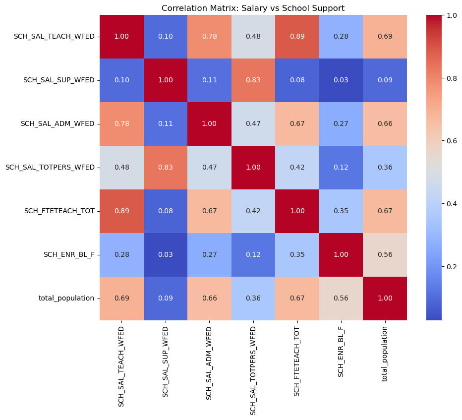

```python
import seaborn as sns
import matplotlib.pyplot as plt

plt.figure(figsize=(10, 8))
sns.heatmap(corr_data.corr(), annot=True, cmap='coolwarm', fmt=".2f")
plt.title("Correlation Matrix: Salary vs School Support")
plt.show()
```

```python
from sklearn.preprocessing import LabelEncoder

# A. Binary (Yes/No)
binary_cols = ['SCH_DUAL_IND', 'SCH_GT_IND', 'SCH_IBENR_IND']
for col in binary_cols:
    feature_df[col] = feature_df[col].fillna('No')  # assume missing = No
    feature_df[col] = LabelEncoder().fit_transform(feature_df[col])  # Yes=1, No=0
```

```python
feature_df.info()
```

```
<class 'pandas.core.frame.DataFrame'>
Index: 1748 entries, 319 to 3342
Data columns (total 42 columns):
 #   Column                Non-Null Count  Dtype
---  ------                --------------  -----
 0   LEA_STATE             1748 non-null   object
 1   LEAID                 1748 non-null   object
 2   SCH_ALTFOCUS          1748 non-null   object
 3   SCH_STATUS_ALT        1748 non-null   object
 4   SCHID                 1748 non-null   int64
 5   SCH_NAME              1748 non-null   object
 6   COMBOKEY              1748 non-null   object
 7   SCH_ENR_BL_F          1748 non-null   float64
 8   TOT_ENR_M             1748 non-null   float64
 9   TOT_ENR_F             1748 non-null   float64
```

[output cut: 34 more lines]

```python
# B. Black Female Counts (normalize if needed) Empty == Assume there are no black girls participating
bf_count_cols = ['SCH_GTENR_BL_F', 'SCH_SATACT_BL_F']
feature_df[bf_count_cols] = feature_df[bf_count_cols].fillna(0)
```

```python
# --- C. Normalize Offense Counts --- We want to model the intensity of the school climate, not absolute numbers

# List of all offense variables
offense_cols = [col for col in feature_df.columns if 'SCH_OFFENSE' in col]

# Fill NA values (assume missing = 0 incidents)
feature_df[offense_cols] = feature_df[offense_cols].fillna(0)
```

```python
# --- D. Mice Imputation for Salary ---
from sklearn.experimental import enable_iterative_imputer  # Required to enable IterativeImputer
from sklearn.impute import IterativeImputer
import pandas as pd

# Define the salary columns you want to impute
salary_cols = [
    'SCH_SAL_TEACH_WFED',
    'SCH_SAL_SUP_WFED',
    'SCH_SAL_ADM_WFED',
    'SCH_SAL_TOTPERS_WFED'
]

# Optional: choose correlated predictors to improve imputation (already part of your df)
mice_features = salary_cols + [
    'SCH_FTETEACH_TOT',
    'SCH_FTECOUNSELORS',
    'SCH_FTESERVICES_SOC',
    'SCH_ENR_BL_F',
    'total_population'
]

# Subset the data
mice_data = feature_df[mice_features].copy()

# Initialize MICE imputer
mice_imputer = IterativeImputer(random_state=42, max_iter=10)

# Fit and transform
mice_imputed = mice_imputer.fit_transform(mice_data)

# Put back into DataFrame
mice_imputed_df = pd.DataFrame(mice_imputed, columns=mice_data.columns, index=mice_data.index)

# Replace the original salary columns in feature_df
feature_df[salary_cols] = mice_imputed_df[salary_cols]
```

```python
# --- E. Normalize FTE Educator Counts ---
fte_support_cols = [
    'SCH_FTETEACH_TOT', 'SCH_FTETEACH_NOTCERT', 'SCH_FTECOUNSELORS',
    'SCH_FTESECURITY_LEO', 'SCH_FTESECURITY_GUA',
    'SCH_FTESERVICES_NUR', 'SCH_FTESERVICES_PSY', 'SCH_FTESERVICES_SOC'
]

# Fill NAs with 0 (assume missing = none)
feature_df[fte_support_cols] = feature_df[fte_support_cols].fillna(0)
```

```python
feature_df.info()
```

```
<class 'pandas.core.frame.DataFrame'>
Index: 1748 entries, 319 to 3342
Data columns (total 42 columns):
 #   Column                Non-Null Count  Dtype
---  ------                --------------  -----
 0   LEA_STATE             1748 non-null   object
 1   LEAID                 1748 non-null   object
 2   SCH_ALTFOCUS          1748 non-null   object
 3   SCH_STATUS_ALT        1748 non-null   object
 4   SCHID                 1748 non-null   int64
 5   SCH_NAME              1748 non-null   object
 6   COMBOKEY              1748 non-null   object
 7   SCH_ENR_BL_F          1748 non-null   float64
 8   TOT_ENR_M             1748 non-null   float64
 9   TOT_ENR_F             1748 non-null   float64
```

[output cut: 34 more lines]

```python
# Decision Tree with Raw Feature Data

from sklearn.tree import DecisionTreeClassifier
from sklearn.model_selection import train_test_split

# X = features with raw values
X = feature_df.select_dtypes(include=[float, int])

# Exclude certain population columns
exclude_cols = ['SCHID', 'total_population', 'SCH_ENR_BL_F', 'TOT_ENR_M', 'TOT_ENR_F', 'SCH_IDEAENR_BL_F', 'SCH_504ENR_BL_F']


X = X.drop(columns=exclude_cols)

y = target_df['composite_harm_flag']

# Train/test split
X_train, X_test, y_train, y_test = train_test_split(X, y, stratify=y, random_state=42)
```

```python
# Train DT
from sklearn.tree import DecisionTreeClassifier

dt_1= DecisionTreeClassifier(max_depth=5, random_state=42)
dt_1.fit(X_train, y_train)
```

```
DecisionTreeClassifier(max_depth=5, random_state=42)
```

```python
# Validation Set Tune DT
# 5 Fold CV
scores = cross_val_score(dt_1, X, y, cv=5)
print(f"Cross-Validation Accuracy Scores: {scores}")
print(f"Mean CV Accuracy: {scores.mean():.4f}")
```

```
Cross-Validation Accuracy Scores: [0.69142857 0.56       0.72285714 0.63323782 0.48424069]
Mean CV Accuracy: 0.6184
```

```python
# Train Model and Test Performance
dt_1.fit(X_train, y_train)
y_pred = dt_1.predict(X_test)

print("Test Set Performance:")
print(classification_report(y_test, y_pred))
print(f"Test Accuracy: {accuracy_score(y_test, y_pred):.4f}")
```

```
Test Set Performance:
              precision    recall  f1-score   support

           0       0.77      0.67      0.72       258
           1       0.60      0.72      0.65       179

    accuracy                           0.69       437
   macro avg       0.69      0.69      0.69       437
weighted avg       0.70      0.69      0.69       437

Test Accuracy: 0.6888
```

```python
#Test
# CCP Pruning the tree

# Train a full Decision Tree
dt_full = DecisionTreeClassifier(class_weight='balanced', random_state=42)
dt_full.fit(X_train, y_train)

# Get CCP Path
path = dt_full.cost_complexity_pruning_path(X_train, y_train)
ccp_alphas = path.ccp_alphas  # List of alpha values

valid_ccp_alphas = [alpha for alpha in ccp_alphas if alpha >= 0.0]

# Train trees with different pruning strengths
pruned_trees = []
for alpha in valid_ccp_alphas:
    dt_pruned = DecisionTreeClassifier(random_state=42, ccp_alpha=alpha, class_weight='balanced')
    dt_pruned.fit(X_train, y_train)
    pruned_trees.append(dt_pruned)
```

```python
# Best CCP_Alpha

best_alpha = None
best_accuracy = 0

for i, alpha in enumerate(valid_ccp_alphas):
    y_pred_val = pruned_trees[i].predict(X_test)
    acc = accuracy_score(y_test, y_pred_val)

    if acc > best_accuracy:
        best_accuracy = acc
        best_alpha = alpha

print(f"Best ccp_alpha for pruning: {best_alpha}")
```

```
Best ccp_alpha for pruning: 0.0062632086286680405
```

```
Final Pruned Decision Tree - Test Performance
              precision    recall  f1-score   support

           0       0.75      0.74      0.74       258
           1       0.63      0.64      0.63       179

    accuracy                           0.70       437
   macro avg       0.69      0.69      0.69       437
weighted avg       0.70      0.70      0.70       437

Test Accuracy: 0.6979
AUC Score: 0.7167
```

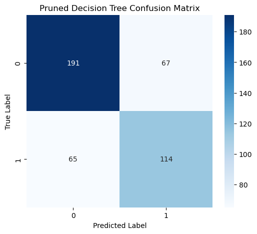

```python
# Train the final Decision Tree with the best pruning level
dt_final = DecisionTreeClassifier(random_state=42, ccp_alpha=best_alpha)
dt_final.fit(X_train, y_train)

# Predict on test set
y_pred_final = dt_final.predict(X_test)
y_probs_final = dt_final.predict_proba(X_test)[:, 1]  # Probabilities for class 1

# Evaluation metrics
print("Final Pruned Decision Tree - Test Performance")
print(classification_report(y_test, y_pred_final))
print(f"Test Accuracy: {accuracy_score(y_test, y_pred_final):.4f}")
print(f"AUC Score: {roc_auc_score(y_test, y_probs_final):.4f}")

# Confusion Matrix
cm = confusion_matrix(y_test, y_pred_final)
plt.figure(figsize=(6, 5))
sns.heatmap(cm, annot=True, fmt='d', cmap='Blues', xticklabels=np.unique(y), yticklabels=np.unique(y))
plt.xlabel("Predicted Label")
plt.ylabel("True Label")
plt.title("Pruned Decision Tree Confusion Matrix")
plt.show()
```

```python
import shap

# Create SHAP explainer for your trained pruned tree
explainer = shap.TreeExplainer(dt_final)
```

```python
shap_values = explainer.shap_values(X_test)
```

```python
print("SHAP values shape:", np.shape(shap_values))  # Should be 2 at the end.
```

```
SHAP values shape: (437, 29, 2)
```

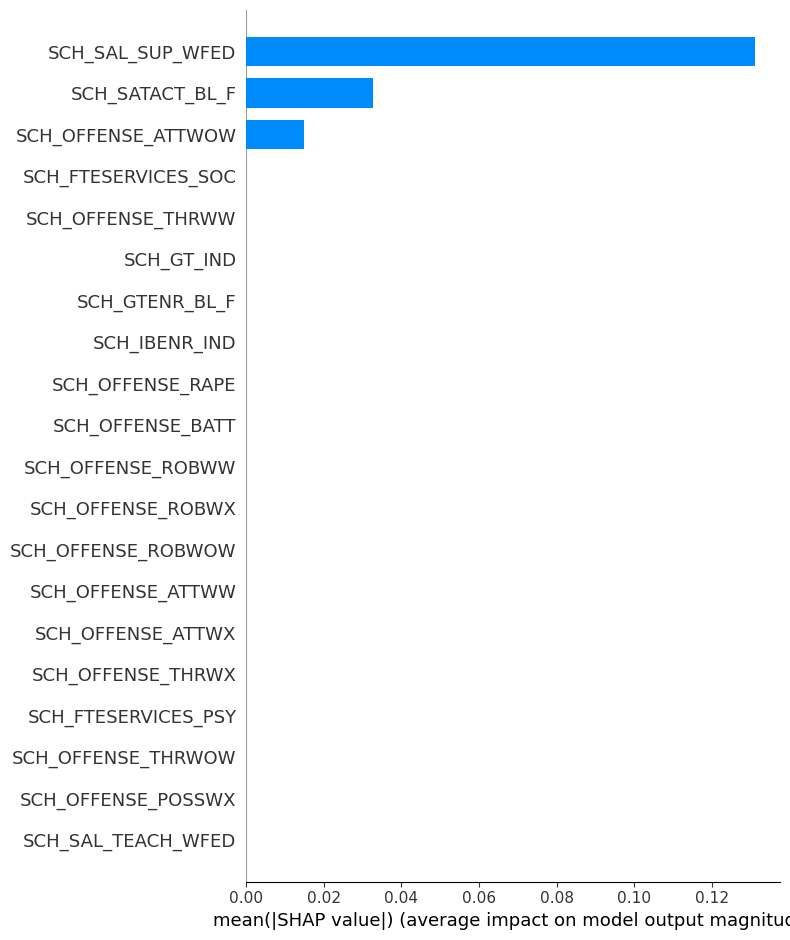

```python
# For class 1 (harm)
shap_values_class1 = shap_values[:, :, 1]

shap.summary_plot(shap_values_class1, X_test, plot_type="bar")
```

```python
shap.summary_plot(shap_values_class1, X_test, show=False)
plt.tight_layout()
plt.savefig("shap_summary_plot.png", dpi=300, bbox_inches='tight')
plt.close()
```

```python
# Normalize by total enrollment (i.e., total student population)
for col in offense_cols:
    feature_df[col + '_rate'] = feature_df[col] / target_df['total_population']
    feature_df[col + '_rate'] = feature_df[col + '_rate'].replace([np.inf, -np.inf], 0).fillna(0)

# Optional: Drop raw counts to reduce dimensionality
feature_df.drop(columns=offense_cols, inplace=True)
```

```python
# Normalize those salary variables
feature_df['total_population'] = feature_df['total_population'].replace(0, np.nan)

# Step 3: Normalize salary columns (post-imputation)
salary_cols = [
    'SCH_SAL_TEACH_WFED',
    'SCH_SAL_SUP_WFED',
    'SCH_SAL_ADM_WFED',
    'SCH_SAL_TOTPERS_WFED'
]

for col in salary_cols:
    rate_col = col + '_per_student'
    feature_df[rate_col] = feature_df[col] / feature_df['total_population']
    feature_df[rate_col] = feature_df[rate_col].replace([np.inf, -np.inf], 0).fillna(0)

# Optional: Drop raw salary columns to reduce collinearity
feature_df.drop(columns=salary_cols, inplace=True)
```

```python
# Normalize by total population
for col in fte_support_cols:
    feature_df[col + '_per_student'] = feature_df[col] / target_df['total_population']
    feature_df[col + '_per_student'] = feature_df[col + '_per_student'].replace([np.inf, -np.inf], 0).fillna(0)

# Optional: Drop original FTE count columns
feature_df.drop(columns=fte_support_cols, inplace=True)
```

```
array([[<Axes: title={'center': 'SCH_SAL_TEACH_WFED_per_student'}>,
        <Axes: title={'center': 'SCH_SAL_SUP_WFED_per_student'}>,
        <Axes: title={'center': 'SCH_SAL_ADM_WFED_per_student'}>],
       [<Axes: title={'center': 'SCH_SAL_TOTPERS_WFED_per_student'}>,
        <Axes: title={'center': 'SCH_FTETEACH_TOT_per_student'}>,
        <Axes: title={'center': 'SCH_FTETEACH_NOTCERT_per_student'}>],
       [<Axes: title={'center': 'SCH_FTECOUNSELORS_per_student'}>,
        <Axes: title={'center': 'SCH_FTESECURITY_LEO_per_student'}>,
        <Axes: title={'center': 'SCH_FTESECURITY_GUA_per_student'}>],
       [<Axes: title={'center': 'SCH_FTESERVICES_NUR_per_student'}>,
        <Axes: title={'center': 'SCH_FTESERVICES_PSY_per_student'}>,
        <Axes: title={'center': 'SCH_FTESERVICES_SOC_per_student'}>]],
      dtype=object)
```

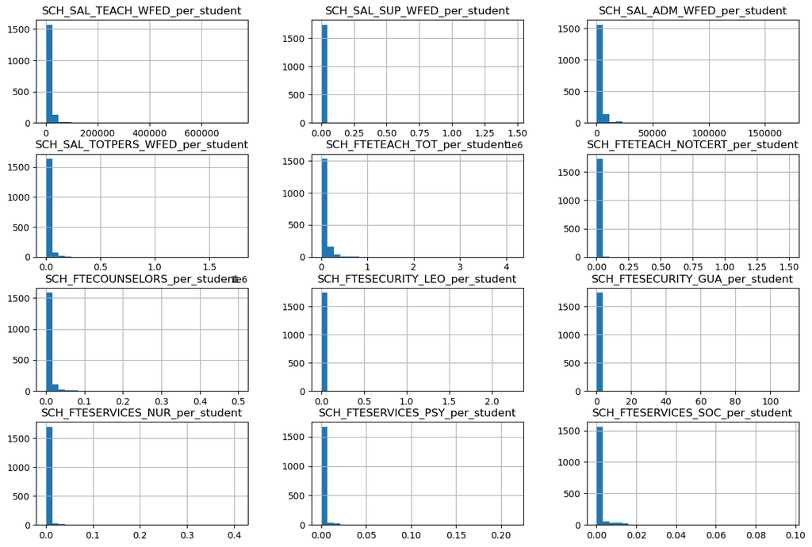

```python
feature_df[[col for col in feature_df.columns if 'per_student' in col]].hist(bins=30, figsize=(15, 10))
```

```python
# Step 1: Select only salary-related '_per_student' columns
salary_log_cols = [col for col in feature_df.columns if col.startswith('SCH_SAL') and col.endswith('_per_student')]

# Step 2: Apply log1p transformation to reduce skew
for col in salary_log_cols:
    feature_df[col + '_log'] = np.log1p(feature_df[col])

# Step 3 (optional): Drop original raw salary '_per_student' columns
feature_df.drop(columns=salary_log_cols, inplace=True)
```

```
array([[<Axes: title={'center': 'SCH_FTETEACH_TOT_per_student'}>,
        <Axes: title={'center': 'SCH_FTETEACH_NOTCERT_per_student'}>,
        <Axes: title={'center': 'SCH_FTECOUNSELORS_per_student'}>],
       [<Axes: title={'center': 'SCH_FTESECURITY_LEO_per_student'}>,
        <Axes: title={'center': 'SCH_FTESECURITY_GUA_per_student'}>,
        <Axes: title={'center': 'SCH_FTESERVICES_NUR_per_student'}>],
       [<Axes: title={'center': 'SCH_FTESERVICES_PSY_per_student'}>,
        <Axes: title={'center': 'SCH_FTESERVICES_SOC_per_student'}>,
        <Axes: title={'center': 'SCH_SAL_TEACH_WFED_per_student_log'}>],
       [<Axes: title={'center': 'SCH_SAL_SUP_WFED_per_student_log'}>,
        <Axes: title={'center': 'SCH_SAL_ADM_WFED_per_student_log'}>,
        <Axes: title={'center': 'SCH_SAL_TOTPERS_WFED_per_student_log'}>]],
      dtype=object)
```

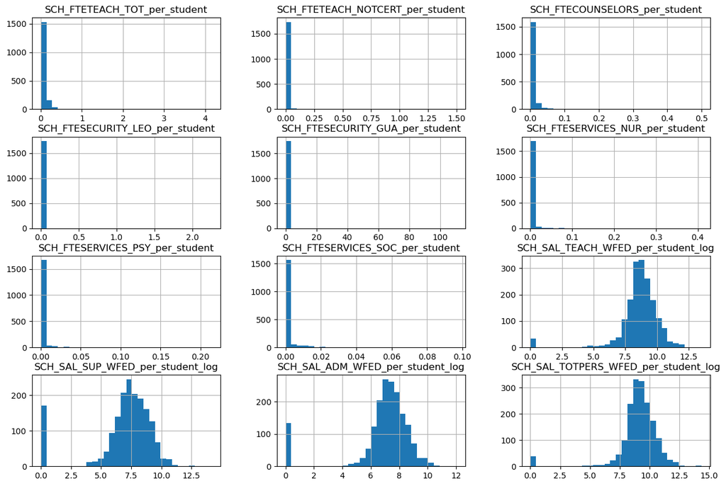

```python
feature_df[[col for col in feature_df.columns if 'per_student' in col]].hist(bins=30, figsize=(15, 10))
```

```python
# Scale
#from sklearn.preprocessing import StandardScaler

# 1. Identify columns to scale (excluding IDs, binaries)
#exclude_cols = ['LEA_STATE', 'LEAID', 'SCHID', 'SCH_NAME', 'COMBOKEY']
#binary_cols = ['SCH_DUAL_IND', 'SCH_GT_IND', 'SCH_IBENR_IND']  # already 0/1 encoded
#numeric_cols = feature_df.select_dtypes(include=['float64', 'int64']).columns.tolist()

# Final columns to scale
#scale_cols = [col for col in numeric_cols if col not in exclude_cols + binary_cols]

# 2. Apply StandardScaler
#scaler = StandardScaler()
#feature_df[scale_cols] = scaler.fit_transform(feature_df[scale_cols])
```

#### Visualizations:

- Harm Map
- Harm Percentage Map

```python
feature_df.info(50)
```

```
<class 'pandas.core.frame.DataFrame'>
Index: 1748 entries, 319 to 3342
Data columns (total 42 columns):
 #   Column                                Non-Null Count  Dtype
---  ------                                --------------  -----
 0   LEA_STATE                             1748 non-null   object
 1   LEAID                                 1748 non-null   object
 2   SCH_ALTFOCUS                          1748 non-null   object
 3   SCH_STATUS_ALT                        1748 non-null   object
 4   SCHID                                 1748 non-null   int64
 5   SCH_NAME                              1748 non-null   object
 6   COMBOKEY                              1748 non-null   object
 7   SCH_ENR_BL_F                          1748 non-null   float64
 8   TOT_ENR_M                             1748 non-null   float64
 9   TOT_ENR_F                             1748 non-null   float64
```

[output cut: 34 more lines]

```python
# Visualizing thresholds
harm_cols = [
    'bf_retention_binary', 'police_involvement_binary', 'restraint_binary',
    'suspension_binary', 'harassment_binary', 'expulsion_binary', 'composite_harm_flag'
]

# Count schools with harm for each indicator
harm_summary = {
    col: int(target_df[col].sum())
    for col in harm_cols
}

# Total number of schools
harm_summary['total_schools'] = target_df.shape[0]

# Create DataFrame
harm_summary_df = pd.DataFrame.from_dict(harm_summary, orient='index', columns=['Number of Schools'])
harm_summary_df
```

|  | Number of Schools |
| --- | --- |
| bf_retention_binary | 345 |
| police_involvement_binary | 202 |
| restraint_binary | 44 |
| suspension_binary | 484 |
| harassment_binary | 57 |
| expulsion_binary | 95 |
| composite_harm_flag | 715 |
| total_schools | 1748 |

```python
pip install geopandas matplotlib pandas
```

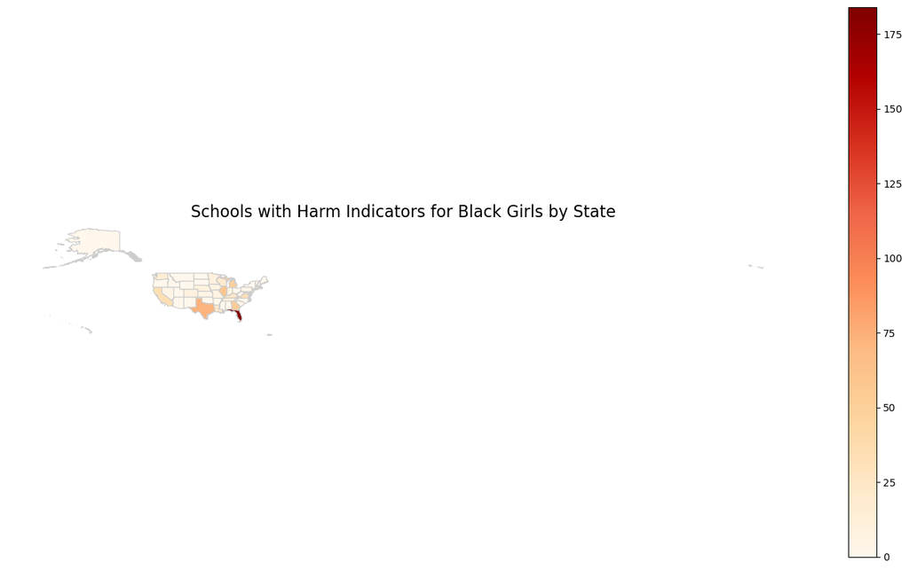

```python
import geopandas as gpd
import pandas as pd
import matplotlib.pyplot as plt
import json

# Step 1: Group by state abbreviation to get number of harmful schools
state_harm = target_df.groupby('LEA_STATE')['composite_harm_flag'].sum().reset_index()
state_harm.columns = ['state_abbr', 'num_harmful_schools']

# Step 2: Load GeoJSON and convert to GeoDataFrame
with open("/Users/joyamelvin/Desktop/gz_2010_us_040_00_500k.json") as f:
    geojson = json.load(f)

states_gdf = gpd.GeoDataFrame.from_features(geojson['features'])

# Step 3: Map state names to abbreviations
state_name_to_abbr = {
    'Alabama': 'AL', 'Alaska': 'AK', 'Arizona': 'AZ', 'Arkansas': 'AR',
    'California': 'CA', 'Colorado': 'CO', 'Connecticut': 'CT', 'Delaware': 'DE',
    'District of Columbia': 'DC', 'Florida': 'FL', 'Georgia': 'GA', 'Hawaii': 'HI',
    'Idaho': 'ID', 'Illinois': 'IL', 'Indiana': 'IN', 'Iowa': 'IA', 'Kansas': 'KS',
    'Kentucky': 'KY', 'Louisiana': 'LA', 'Maine': 'ME', 'Maryland': 'MD',
    'Massachusetts': 'MA', 'Michigan': 'MI', 'Minnesota': 'MN', 'Mississippi': 'MS',
    'Missouri': 'MO', 'Montana': 'MT', 'Nebraska': 'NE', 'Nevada': 'NV',
    'New Hampshire': 'NH', 'New Jersey': 'NJ', 'New Mexico': 'NM', 'New York': 'NY',
    'North Carolina': 'NC', 'North Dakota': 'ND', 'Ohio': 'OH', 'Oklahoma': 'OK',
    'Oregon': 'OR', 'Pennsylvania': 'PA', 'Rhode Island': 'RI', 'South Carolina': 'SC',
    'South Dakota': 'SD', 'Tennessee': 'TN', 'Texas': 'TX', 'Utah': 'UT',
    'Vermont': 'VT', 'Virginia': 'VA', 'Washington': 'WA', 'West Virginia': 'WV',
    'Wisconsin': 'WI', 'Wyoming': 'WY'
}

states_gdf['STATE_ABBR'] = states_gdf['NAME'].map(state_name_to_abbr)

# Step 4: Merge harm data with shapefile data
merged = states_gdf.merge(state_harm, how='left', left_on='STATE_ABBR', right_on='state_abbr')
merged['num_harmful_schools'] = merged['num_harmful_schools'].fillna(0)

# Step 5: Plot
fig, ax = plt.subplots(figsize=(14, 8))
merged.plot(column='num_harmful_schools',
            cmap='OrRd',
            linewidth=0.8,
            ax=ax,
            edgecolor='0.8',
            legend=True)

ax.set_title('Schools with Harm Indicators for Black Girls by State', fontsize=16)
ax.axis('off')
plt.tight_layout()
plt.savefig("harm_schools_by_state.png", dpi=300)
plt.show()
```

```python
# Filter to lower 48 states only (exclude AK, HI, PR, etc.)
lower48 = merged.cx[-125:-66, 24:50]  # longitude, then latitude
```

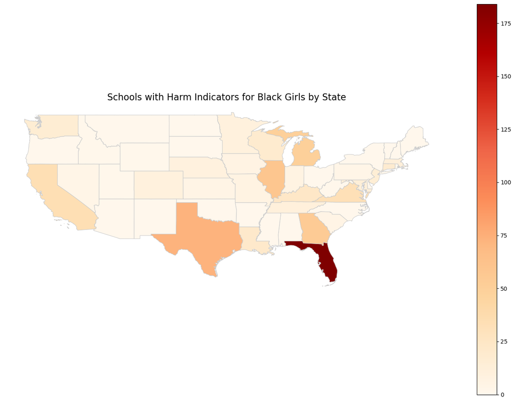

```python
fig, ax = plt.subplots(figsize=(14, 10))  # Adjust aspect ratio for better visibility
lower48.plot(column='num_harmful_schools',
             cmap='OrRd',
             linewidth=0.8,
             ax=ax,
             edgecolor='0.8',
             legend=True)

ax.set_title('Schools with Harm Indicators for Black Girls by State', fontsize=16)
ax.axis('off')
plt.tight_layout()
plt.savefig("harm_schools_by_state_continental.png", dpi=300)
plt.show()
```

```python
# Total alt schools per state
total_schools_by_state = target_df.groupby('LEA_STATE').size().reset_index(name='total_alt_schools')

# Harm-flagged schools per state
harm_schools_by_state = target_df.groupby('LEA_STATE')['composite_harm_flag'].sum().reset_index(name='harmful_alt_schools')

# Merge counts
harm_rate = pd.merge(total_schools_by_state, harm_schools_by_state, on='LEA_STATE')

# Compute harm percentage
harm_rate['harm_pct'] = (harm_rate['harmful_alt_schools'] / harm_rate['total_alt_schools']) * 100
```

```python
states_gdf['STATE_ABBR'] = states_gdf['NAME'].map(state_name_to_abbr)
```

```python
merged_pct = states_gdf.merge(harm_rate, how='left', left_on='STATE_ABBR', right_on='LEA_STATE')
merged_pct['harm_pct'] = merged_pct['harm_pct'].fillna(0)
```

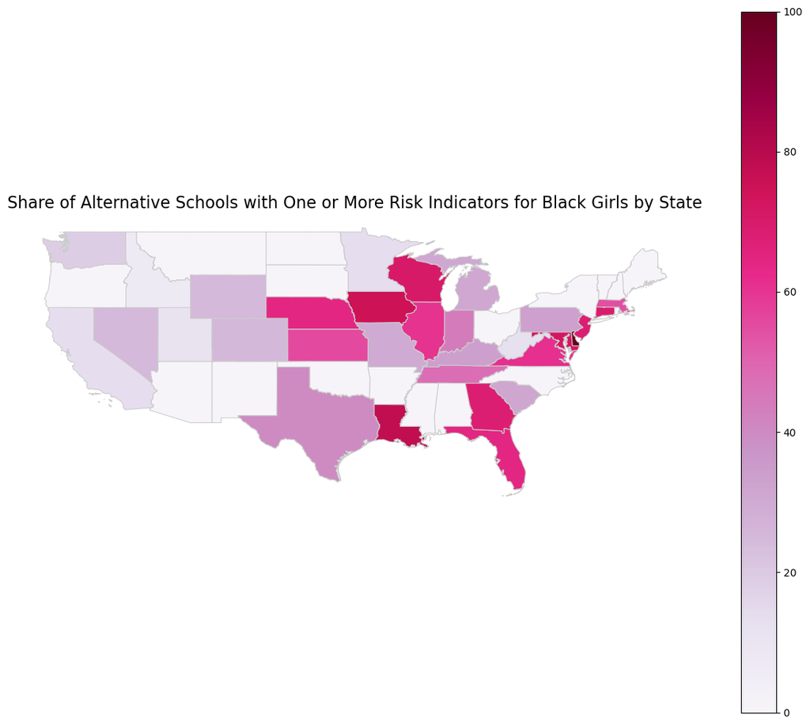

```python
lower48 = merged_pct.cx[-125:-66, 24:50]

# Plot with larger figure size

fig, ax = plt.subplots(figsize=(12, 10))

lower48.plot(column='harm_pct',
             cmap='PuRd',
             linewidth=0.8,
             ax=ax,
             edgecolor='0.8',
             legend=True)

ax.set_title('Share of Alternative Schools with One or More Risk Indicators for Black Girls by State', fontsize=16)
ax.axis('off')
plt.tight_layout()
plt.savefig("harm_pct_by_state_large.png", dpi=300)
plt.show()
```

```python
state_funding = feature_df.groupby("LEA_STATE")["SCH_SAL_TOTPERS_WFED_per_student_log"].mean().reset_index()
state_funding.columns = ['state_abbr', 'avg_funding_per_student_log']


# Load GeoJSON
with open("/Users/joyamelvin/Desktop/gz_2010_us_040_00_500k.json") as f:
    geojson = json.load(f)

states_gdf = gpd.GeoDataFrame.from_features(geojson['features'])

# Match abbreviations
state_name_to_abbr = {
    'Alabama': 'AL', 'Alaska': 'AK', 'Arizona': 'AZ', 'Arkansas': 'AR',
    'California': 'CA', 'Colorado': 'CO', 'Connecticut': 'CT', 'Delaware': 'DE',
    'District of Columbia': 'DC', 'Florida': 'FL', 'Georgia': 'GA', 'Hawaii': 'HI',
    'Idaho': 'ID', 'Illinois': 'IL', 'Indiana': 'IN', 'Iowa': 'IA', 'Kansas': 'KS',
    'Kentucky': 'KY', 'Louisiana': 'LA', 'Maine': 'ME', 'Maryland': 'MD',
    'Massachusetts': 'MA', 'Michigan': 'MI', 'Minnesota': 'MN', 'Mississippi': 'MS',
    'Missouri': 'MO', 'Montana': 'MT', 'Nebraska': 'NE', 'Nevada': 'NV',
    'New Hampshire': 'NH', 'New Jersey': 'NJ', 'New Mexico': 'NM', 'New York': 'NY',
    'North Carolina': 'NC', 'North Dakota': 'ND', 'Ohio': 'OH', 'Oklahoma': 'OK',
    'Oregon': 'OR', 'Pennsylvania': 'PA', 'Rhode Island': 'RI', 'South Carolina': 'SC',
    'South Dakota': 'SD', 'Tennessee': 'TN', 'Texas': 'TX', 'Utah': 'UT',
    'Vermont': 'VT', 'Virginia': 'VA', 'Washington': 'WA', 'West Virginia': 'WV',
    'Wisconsin': 'WI', 'Wyoming': 'WY'
}
# use your mapping
states_gdf['state_abbr'] = states_gdf['NAME'].map(state_name_to_abbr)

merged = states_gdf.merge(state_funding, on='state_abbr', how='left')
```

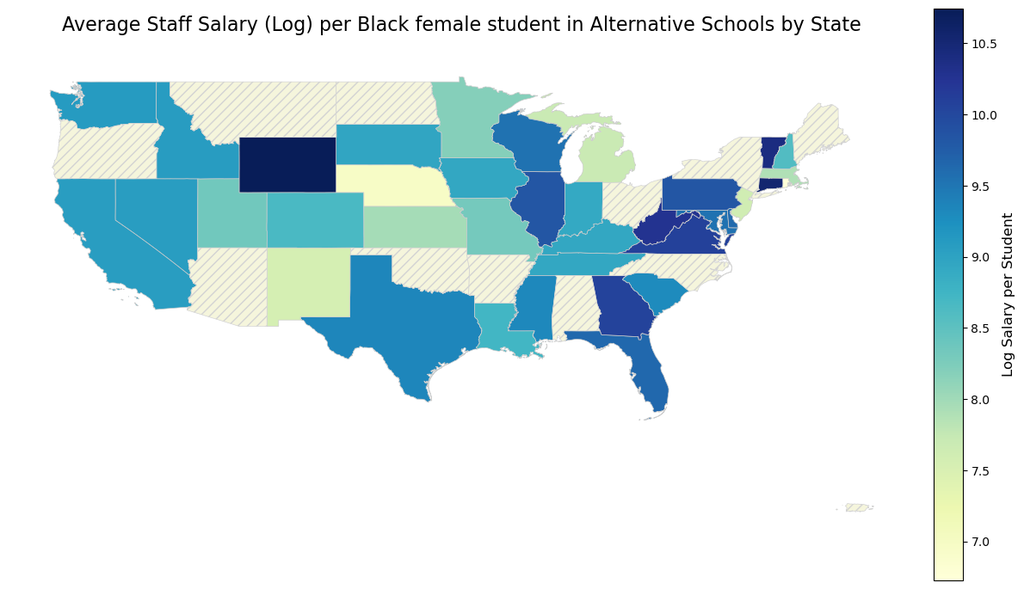

```python
import matplotlib.pyplot as plt
import matplotlib as mpl

# Filter to only continental U.S. states
continental_merged = merged[~merged['state_abbr'].isin(['AK', 'HI'])]

# Set up larger figure size
fig, ax = plt.subplots(figsize=(12, 10))  # Tall and wide

blue_cmap = plt.cm.YlGnBu

# Plot the continental states
continental_merged.plot(
    column='avg_funding_per_student_log',
    cmap=blue_cmap,
    linewidth=0.5,
    edgecolor='0.8',
    legend=False,
    ax=ax,
    missing_kwds={
        "color": "#f5f5dc",       # Light beige
        "edgecolor": "lightgrey",
        "hatch": "///",
        "label": "Missing data"
    }
)

# Add custom colorbar
norm = mpl.colors.Normalize(
    vmin=continental_merged['avg_funding_per_student_log'].min(),
    vmax=continental_merged['avg_funding_per_student_log'].max()
)
sm = mpl.cm.ScalarMappable(cmap='YlGnBu', norm=norm)
sm._A = []

cbar = fig.colorbar(sm, ax=ax, fraction=0.03, pad=0.02)
cbar.set_label("Log Salary per Student", fontsize=12)

# Title and layout
ax.set_title('Average Staff Salary (Log) per Black female student in Alternative Schools by State', fontsize=16, pad=20)
ax.axis('off')

plt.tight_layout()
plt.savefig("funding_map_alt_schools_larger_continental.png", dpi=300, bbox_inches='tight')
plt.show()
```

```python
all_states = set(states_gdf['state_abbr'])  # All states in the map
data_states = set(feature_df['LEA_STATE'].unique())  # States in your dataset

missing_states = all_states - data_states
print("States with no data:", missing_states)
```

```
States with no data: {'OR', 'HI', 'AK', 'MT', 'AL', 'ME', 'NC', 'AZ', 'OK', 'OH', 'AR', nan, 'NY', 'ND'}
```

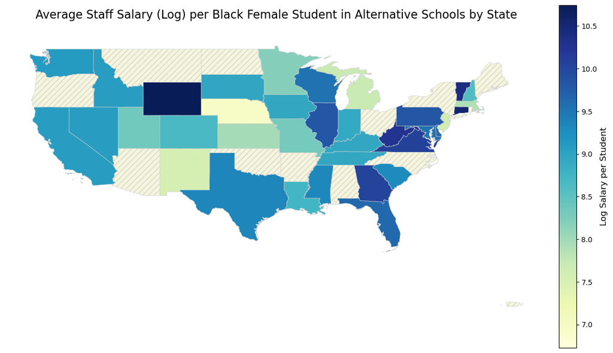

```python
import matplotlib.pyplot as plt
import matplotlib as mpl

# Filter to only continental U.S. states
continental_merged = merged[~merged['state_abbr'].isin(['AK', 'HI'])]

# Set up larger figure size
fig, ax = plt.subplots(figsize=(12, 10))  # Tall and wide

blue_cmap = plt.cm.YlGnBu  # Blue-themed colormap

# Plot the continental states
continental_merged.plot(
    column='avg_funding_per_student_log',
    cmap=blue_cmap,
    linewidth=0.5,
    edgecolor='0.8',
    legend=False,
    ax=ax,
    missing_kwds={
        "color": "#f5f5dc",       # Light beige
        "edgecolor": "lightgrey",
        "hatch": "///",
        "label": "Missing data"
    }
)

# Add custom colorbar
norm = mpl.colors.Normalize(
    vmin=continental_merged['avg_funding_per_student_log'].min(),
    vmax=continental_merged['avg_funding_per_student_log'].max()
)
sm = mpl.cm.ScalarMappable(cmap=blue_cmap, norm=norm)
sm._A = []

cbar = fig.colorbar(sm, ax=ax, fraction=0.03, pad=0.02)
cbar.set_label("Log Salary per Student", fontsize=12)

# Title and layout
ax.set_title('Average Staff Salary (Log) per Black Female Student in Alternative Schools by State', fontsize=16, pad=20)
ax.axis('off')

plt.tight_layout()
plt.savefig("funding_map_alt_schools_larger_continental.png", dpi=300, bbox_inches='tight')
plt.show()
```

## III. Model Selection - Random Forest & XGBoost

- Data preparation for analysis (including train/test splits).
- Model training.
- Model/Performance assessment and metrics.
- Hyperparameter selection/tuning.
- Post-tuning reassessment.

```python
from sklearn.model_selection import train_test_split

# List of ID or non-predictive columns to exclude
id_cols = ['LEA_STATE', 'LEAID', 'SCH_ALTFOCUS', 'SCH_STATUS_ALT', 'SCHID', 'SCH_NAME', 'COMBOKEY', 'SCH_ENR_BL_F', 'TOT_ENR_M', 'TOT_ENR_F',
          'SCH_IDEAENR_BL_F', 'SCH_504ENR_BL_F', 'total_population']

# Drop ID columns from features
X = feature_df.drop(columns=id_cols, errors='ignore')  # errors='ignore' skips any missing ones safely

# Target variable (e.g., composite harm flag)
y = target_df['composite_harm_flag']

# Stratified split to preserve class distribution
X_train, X_test, y_train, y_test = train_test_split(
    X, y, test_size=0.2, stratify=y, random_state=42
)

# Shapes for confirmation
print("X_train:", X_train.shape)
print("X_test:", X_test.shape)
print("y_train:", y_train.shape)
print("y_test:", y_test.shape)
```

```
X_train: (1398, 29)
X_test: (350, 29)
y_train: (1398,)
y_test: (350,)
```

```python
# Scale
from sklearn.preprocessing import StandardScaler
# 2. Scale ONLY numeric columns (excluding binaries and IDs)
numeric_cols = X.select_dtypes(include=['float64', 'int64']).columns.tolist()
scale_cols = [col for col in numeric_cols if col not in binary_cols]

# 3. Apply scaling to training and test separately
scaler = StandardScaler()
X_train[scale_cols] = scaler.fit_transform(X_train[scale_cols])
X_test[scale_cols] = scaler.transform(X_test[scale_cols])
```

#### 1. Log Reg

- Favor high recall: Want to make sure I am catching the most harmful environments for black girls.

```python
# 1. LogReg
from sklearn.linear_model import LogisticRegression

logreg = LogisticRegression(max_iter=1000, random_state=42)
logreg.fit(X_train, y_train)
```

```
LogisticRegression(max_iter=1000, random_state=42)
```

```
Baseline Logistic Regression Performance:
              precision    recall  f1-score   support

           0       0.59      0.89      0.71       207
           1       0.37      0.09      0.15       143

    accuracy                           0.57       350
   macro avg       0.48      0.49      0.43       350
weighted avg       0.50      0.57      0.48       350

Accuracy Score: 0.5657142857142857
AUC Score: 0.6325
```

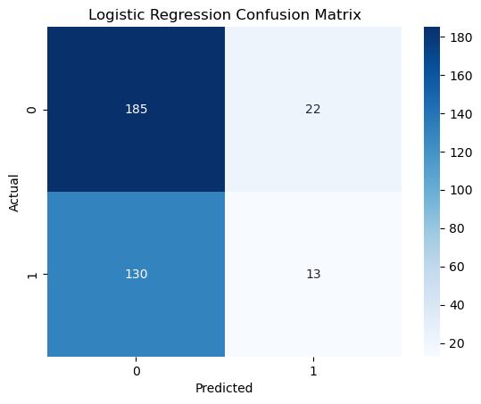

```python
# 1. LogReg Performance Assessment
# Predict and evaluate
y_pred = logreg.predict(X_test)
print("Baseline Logistic Regression Performance:")
print(classification_report(y_test, y_pred))
print("Accuracy Score:", accuracy_score(y_test, y_pred))

# AUC Score
y_probs = logreg.predict_proba(X_test)[:, 1]  # Probabilities for class 1
auc = roc_auc_score(y_test, y_probs)
print(f"AUC Score: {auc:.4f}")

# Plot confusion matrix
conf_matrix = confusion_matrix(y_test, y_pred)
sns.heatmap(conf_matrix, annot=True, fmt='d', cmap='Blues')
plt.title("Logistic Regression Confusion Matrix")
plt.xlabel("Predicted")
plt.ylabel("Actual")
plt.show()
```

```python
# Using GridSearch to find the best params
param_grid = {
    'C': [0.01, 0.1, 1, 10, 100],
    'penalty': ['l1', 'l2'],
    'solver': ['liblinear', 'saga'],
    'class_weight': [None, 'balanced']
}

grid = GridSearchCV(LogisticRegression(max_iter=1000, class_weight='balanced'),
                    param_grid, cv=5, scoring='f1')
grid.fit(X_train, y_train)

print("Best Parameters:", grid.best_params_)
```

```
Best Parameters: {'C': 0.1, 'class_weight': 'balanced', 'penalty': 'l2', 'solver': 'liblinear'}
```

```
Post-Tuning Logistic Regression Performance:
              precision    recall  f1-score   support

           0       0.80      0.47      0.60       207
           1       0.52      0.83      0.64       143

    accuracy                           0.62       350
   macro avg       0.66      0.65      0.62       350
weighted avg       0.69      0.62      0.61       350

Accuracy: 0.62
AUC Score: 0.6319
```

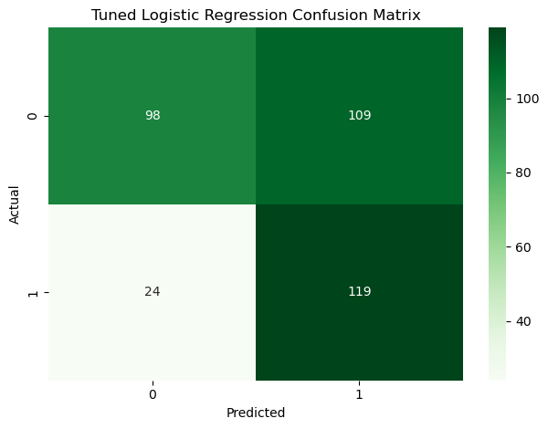

```python
# Predict with best estimator
best_log_reg = grid.best_estimator_
y_pred_best = best_log_reg.predict(X_test)

print("Post-Tuning Logistic Regression Performance:")
print(classification_report(y_test, y_pred_best))
print("Accuracy:", accuracy_score(y_test, y_pred_best))

# AUC Score
y_probs = best_log_reg.predict_proba(X_test)[:, 1]  # Probabilities for class 1
auc = roc_auc_score(y_test, y_probs)
print(f"AUC Score: {auc:.4f}")

# Confusion matrix
conf_mat_best = confusion_matrix(y_test, y_pred_best)
sns.heatmap(conf_mat_best, annot=True, fmt="d", cmap="Greens")
plt.title("Tuned Logistic Regression Confusion Matrix")
plt.xlabel("Predicted")
plt.ylabel("Actual")
plt.tight_layout()
plt.savefig("log_reg_confusion_matrix.png", dpi=300, bbox_inches='tight')
plt.show()
```

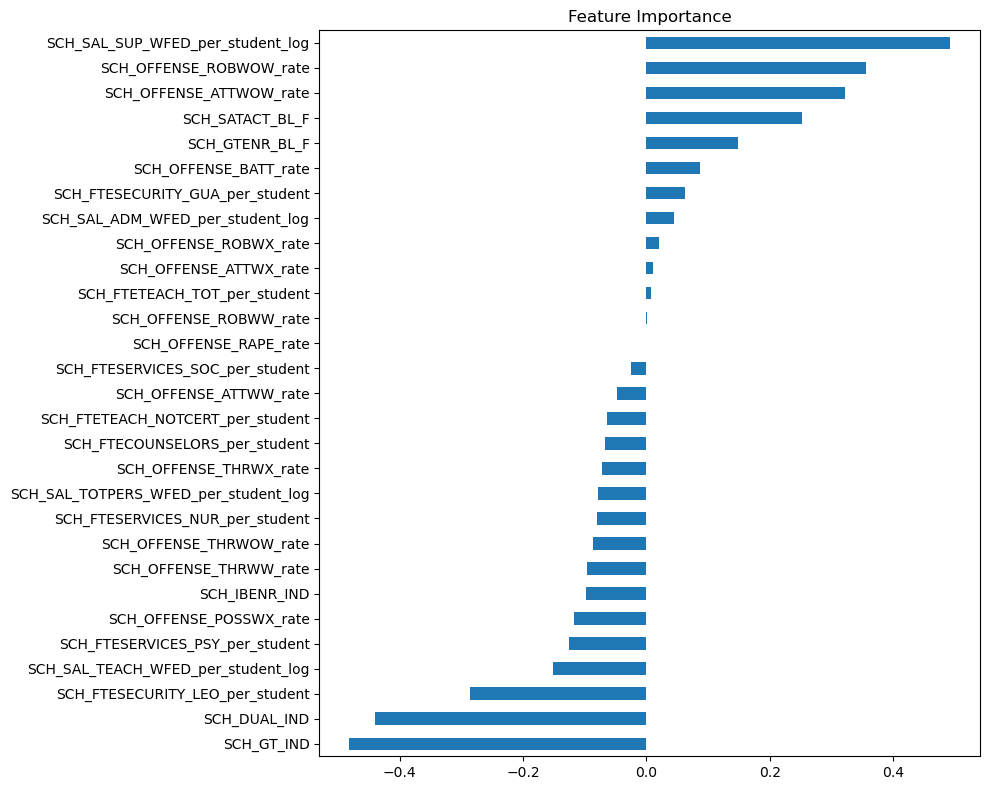

```python
# Interpret coefficients

coeffs = pd.Series(best_log_reg.coef_[0], index=X_train.columns)
coeffs.sort_values().plot(kind='barh', figsize=(10, 8), title='Feature Importance')
plt.tight_layout()
plt.savefig("log_reg_feature_importance.png", dpi=300, bbox_inches='tight')
plt.show()
```

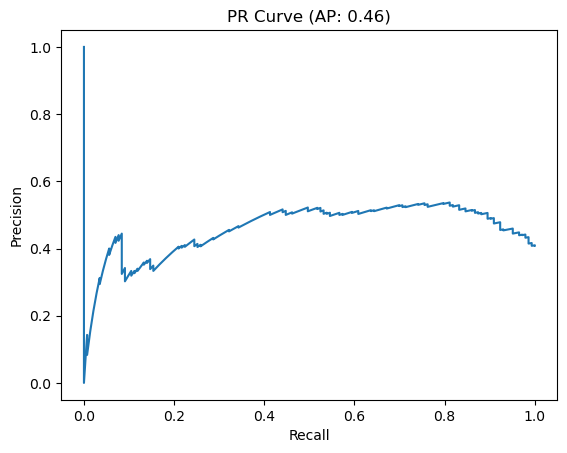

```python
from sklearn.metrics import precision_recall_curve, average_precision_score

precision, recall, _ = precision_recall_curve(y_test, y_probs)
plt.plot(recall, precision)
plt.xlabel('Recall')
plt.ylabel('Precision')
plt.title(f'PR Curve (AP: {average_precision_score(y_test, y_probs):.2f})')
plt.show()
```

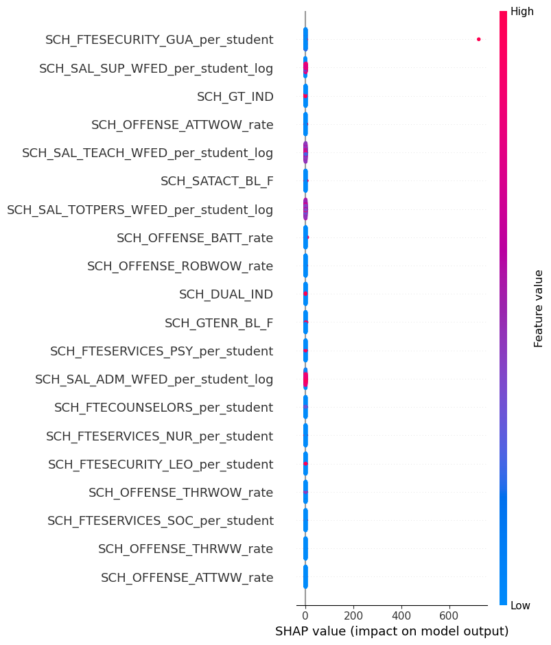

```python
!pip install shap
import shap
# Initialize SHAP explainer for Logistic Regression
explainer = shap.Explainer(best_log_reg, X_test)

# Compute SHAP values
shap_values = explainer(X_test)

# Summary plot for PCA components
shap.summary_plot(shap_values, X_test)
```

```python
# Average Precision = 0.46; LogReg model has moderate (coin-toss) ability to identify harmful school environments correctly.
```

#### 2. Random Forest

```python
# 2. Random Forest
from sklearn.ensemble import RandomForestClassifier

rf = RandomForestClassifier(n_estimators=100, random_state=42)
rf.fit(X_train, y_train)

#create predictions
y_pred_rf = rf.predict(X_test)
y_probs = rf.predict_proba(X_test)[:, 1]
```

```python
#evaluate model
r2_rf = r2_score(y_test, y_pred_rf)
rmse_rf = np.sqrt(mean_squared_error(y_test, y_pred_rf))
```

```
Baseline Random Forest Performance:
              precision    recall  f1-score   support

           0       0.69      0.81      0.74       207
           1       0.63      0.46      0.53       143

    accuracy                           0.67       350
   macro avg       0.66      0.64      0.64       350
weighted avg       0.66      0.67      0.66       350

Accuracy Score: 0.6685714285714286
RMSE: 0.5756983337031395
R^2: -0.37157528461876277
AUC Score: 0.6638
```

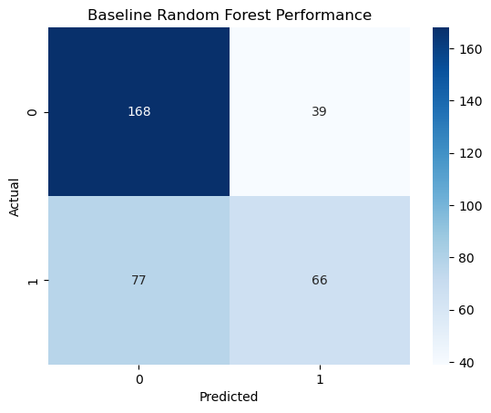

```python
# Predict and evaluate
print("Baseline Random Forest Performance:")
print(classification_report(y_test, y_pred_rf))
r2_rf = r2_score(y_test, y_pred_rf)
rmse_rf = np.sqrt(mean_squared_error(y_test, y_pred_rf))
print("Accuracy Score:", accuracy_score(y_test, y_pred_rf))
print("RMSE:", rmse_rf)
print("R^2:", r2_rf)

# AUC Score
auc = roc_auc_score(y_test, y_probs)
print(f"AUC Score: {auc:.4f}")

# Plot confusion matrix
conf_matrix = confusion_matrix(y_test, y_pred_rf)
sns.heatmap(conf_matrix, annot=True, fmt='d', cmap='Blues')
plt.title("Baseline Random Forest Performance")
plt.xlabel("Predicted")
plt.ylabel("Actual")
plt.show()
```

```python
from sklearn.model_selection import RandomizedSearchCV
from sklearn.ensemble import RandomForestClassifier
import numpy as np

# Define the hyperparameter distribution
rf_param_dist = {
    'n_estimators': [100, 200, 300, 400, 500],
    'max_depth': [5, 10, 15, 20, None],
    'min_samples_split': [2, 5, 10],
    'min_samples_leaf': [1, 2, 4],
    'max_features': ['sqrt', 'log2', None],
    'bootstrap': [True, False],
    'criterion': ['gini', 'entropy']
}

# Initialize the base RF model
rf_base = RandomForestClassifier(random_state=42)

# Randomized Search CV with 50 iterations
random_search_rf = RandomizedSearchCV(
    estimator=rf_base,
    param_distributions=rf_param_dist,
    n_iter=50,  # Try 50 random combinations
    cv=3,
    scoring='f1',
    verbose=2,
    random_state=42,
    n_jobs=-1
)

# Fit the random search
random_search_rf.fit(X_train, y_train)

# Best parameters
print("Best parameters from RandomizedSearchCV:", random_search_rf.best_params_)

# Best estimator
best_rf = random_search_rf.best_estimator_
```

```
Fitting 3 folds for each of 50 candidates, totalling 150 fits
Best parameters from RandomizedSearchCV: {'n_estimators': 100, 'min_samples_split': 5, 'min_samples_leaf': 4, 'max_features': 'sqrt', 'max_depth': 10, 'criterion': 'entropy', 'bootstrap': True}
```

```
Post-Tuning Classification Report:
               precision    recall  f1-score   support

           0       0.71      0.76      0.73       207
           1       0.61      0.54      0.57       143

    accuracy                           0.67       350
   macro avg       0.66      0.65      0.65       350
weighted avg       0.67      0.67      0.67       350

Accuracy: 0.6714285714285714
```

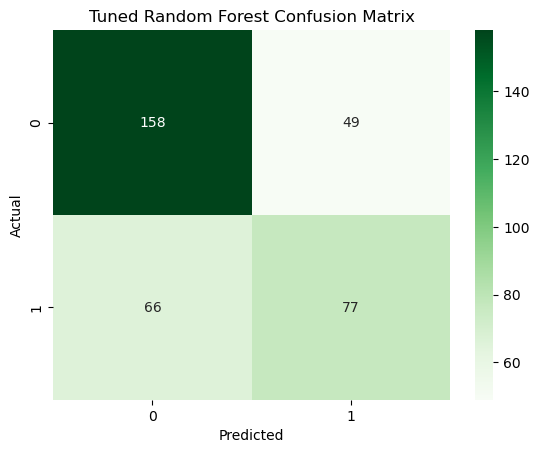

```
AUC Score: 0.7617
Tuned Random Forest R²: -0.3598
Tuned Random Forest RMSE: 0.5732
```

```python
# Post-Tuning Assessment
best_rf = random_search_rf.best_estimator_
y_pred_rf_best = best_rf.predict(X_test)

print("Post-Tuning Classification Report:\n", classification_report(y_test, y_pred_rf_best))
print("Accuracy:", accuracy_score(y_test, y_pred_rf_best))

# Confusion matrix
sns.heatmap(confusion_matrix(y_test, y_pred_rf_best), annot=True, fmt='d', cmap='Greens')
plt.title("Tuned Random Forest Confusion Matrix")
plt.xlabel("Predicted")
plt.ylabel("Actual")
plt.show()

# AUC Score
y_probs_best = best_rf.predict_proba(X_test)[:, 1]
print(f"AUC Score: {roc_auc_score(y_test, y_probs_best):.4f}")

# get RMSE and R2
r2_rf_best = r2_score(y_test, y_pred_rf_best)
rmse_rf_best = np.sqrt(mean_squared_error(y_test, y_pred_rf_best))

print(f"Tuned Random Forest R²: {r2_rf_best:.4f}")
print(f"Tuned Random Forest RMSE: {rmse_rf_best:.4f}")
```

```python
# Feature Importances
importances = best_rf.feature_importances_
feature_names = X_train.columns
rf_importance_df = pd.DataFrame({'feature': feature_names, 'importance': importances})
rf_importance_df.sort_values(by='importance', ascending=False).head(10)
```

|  | feature | importance |
| --- | --- | --- |
| 17 | SCH_FTETEACH_TOT_per_student | 0.149118 |
| 26 | SCH_SAL_SUP_WFED_per_student_log | 0.136858 |
| 28 | SCH_SAL_TOTPERS_WFED_per_student_log | 0.087933 |
| 27 | SCH_SAL_ADM_WFED_per_student_log | 0.086921 |
| 4 | SCH_SATACT_BL_F | 0.083164 |
| 25 | SCH_SAL_TEACH_WFED_per_student_log | 0.076489 |
| 12 | SCH_OFFENSE_ATTWOW_rate | 0.068658 |
| 19 | SCH_FTECOUNSELORS_per_student | 0.062083 |
| 22 | SCH_FTESERVICES_NUR_per_student | 0.036725 |
| 15 | SCH_OFFENSE_THRWOW_rate | 0.032929 |

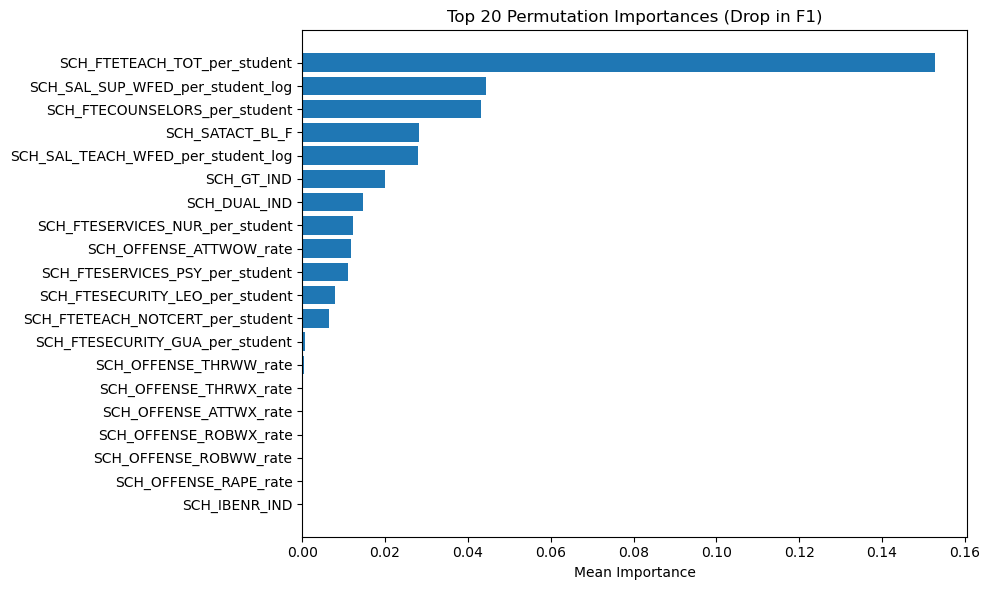

```python
from sklearn.inspection import permutation_importance

result = permutation_importance(best_rf, X_test, y_test, n_repeats=10, random_state=42, scoring='f1')

# Create dataframe
perm_df = pd.DataFrame({
    'Feature': X.columns,
    'Importance': result.importances_mean,
    'Std': result.importances_std
}).sort_values(by='Importance', ascending=False)

# Plot
plt.figure(figsize=(10, 6))
plt.barh(perm_df['Feature'][:20], perm_df['Importance'][:20])
plt.gca().invert_yaxis()
plt.title('Top 20 Permutation Importances (Drop in F1)')
plt.xlabel('Mean Importance')
plt.tight_layout()
plt.savefig("rf_feature_importance.png", dpi=300, bbox_inches='tight')
plt.show()
```

```python
# composite_harm_flag:
# 0 = 1033
# 1 = 715
scale_pos_weight = 1033 / 715
```

#### 3. XGBoost

```python
# 3. XGBoost
from xgboost import XGBClassifier

xgb = XGBClassifier(use_label_encoder=False, eval_metric='logloss', scale_pos_weight=scale_pos_weight, random_state=42)
xgb.fit(X_train, y_train)

y_pred_xgb = xgb.predict(X_test)
y_probs_xgb = xgb.predict_proba(X_test)[:, 1]
```

```
XGBoost Classification Report:
               precision    recall  f1-score   support

           0       0.71      0.70      0.71       207
           1       0.58      0.59      0.59       143

    accuracy                           0.66       350
   macro avg       0.65      0.65      0.65       350
weighted avg       0.66      0.66      0.66       350

Accuracy: 0.6571428571428571
AUC Score: 0.7104658626397757
```

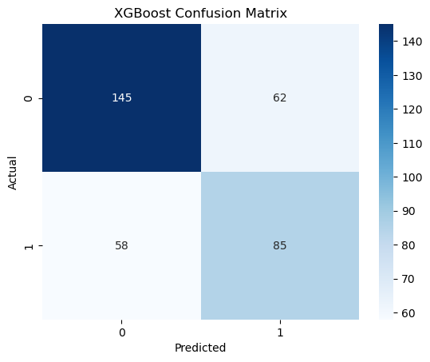

```python
# Model Assessment
print("XGBoost Classification Report:\n", classification_report(y_test, y_pred_xgb))
print("Accuracy:", accuracy_score(y_test, y_pred_xgb))
print("AUC Score:", roc_auc_score(y_test, y_probs_xgb))

# Confusion Matrix
sns.heatmap(confusion_matrix(y_test, y_pred_xgb), annot=True, fmt='d', cmap='Blues')
plt.title("XGBoost Confusion Matrix")
plt.xlabel("Predicted")
plt.ylabel("Actual")
plt.show()
```

```python
# Hyperparameter Tuning
# Define parameter grid for Randomized Search
xgb_param_grid = {
    'n_estimators': [50, 100, 200, 500],
    'learning_rate': [0.01, 0.05, 0.1, 0.3],
    'max_depth': [3, 5, 10],
    'subsample': [0.6, 0.8, 1.0],
    'colsample_bytree': [0.6, 0.8, 1.0],
    'gamma': [0, 0.1, 0.2, 0.5],
    'reg_alpha': [0, 0.1, 0.5, 1.0],
    'reg_lambda': [0.1, 0.5, 1.0],
    'scale_pos_weight': [1.0, 1.2, 1.4, 1.5, 2.0]
}

#performing random search (since grid search took a minute)
random_search_xgb = RandomizedSearchCV(xgb, xgb_param_grid, cv=3, scoring='neg_root_mean_squared_error', n_iter=100-50, n_jobs=-1, verbose=2, random_state=42)
random_search_xgb.fit(X_train, y_train)
```

```
Fitting 3 folds for each of 50 candidates, totalling 150 fits
```

[output not shown]

[output cut: 545 more lines]

[output not shown]

```
RandomizedSearchCV(cv=3,
                   estimator=XGBClassifier(base_score=None, booster=None,
                                           callbacks=None,
                                           colsample_bylevel=None,
                                           colsample_bynode=None,
                                           colsample_bytree=None, device=None,
                                           early_stopping_rounds=None,
                                           enable_categorical=False,
                                           eval_metric='logloss',
                                           feature_types=None,
                                           feature_weights=None, gamma=None,
                                           grow_policy=None,
                                           importance_type=None,
                                           interaction_cons...
                   param_distributions={'colsample_bytree': [0.6, 0.8, 1.0],
                                        'gamma': [0, 0.1, 0.2, 0.5],
                                        'learning_rate': [0.01, 0.05, 0.1, 0.3],
                                        'max_depth': [3, 5, 10],
                                        'n_estimators': [50, 100, 200, 500],
                                        'reg_alpha': [0, 0.1, 0.5, 1.0],
                                        'reg_lambda': [0.1, 0.5, 1.0],
                                        'scale_pos_weight': [1.0, 1.2, 1.4, 1.5,
                                                             2.0],
                                        'subsample': [0.6, 0.8, 1.0]},
                   random_state=42, scoring='neg_root_mean_squared_error',
                   verbose=2)
```

```
Post-Tuning Classification Report:
               precision    recall  f1-score   support

           0       0.70      0.78      0.74       207
           1       0.62      0.52      0.56       143

    accuracy                           0.67       350
   macro avg       0.66      0.65      0.65       350
weighted avg       0.67      0.67      0.67       350

Accuracy: 0.6742857142857143
```

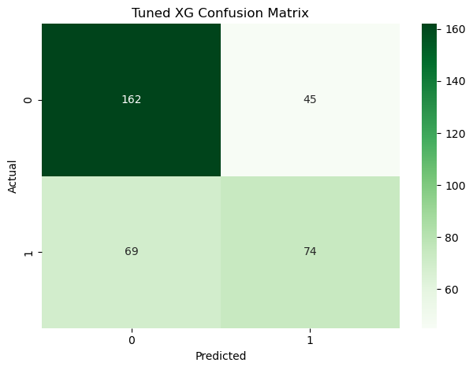

```
AUC Score: 0.7589
Tuned XGB R²: -0.3479
Tuned XGB RMSE: 0.5707
```

```python
# Post-Tuning Assesment
best_xgb = random_search_xgb.best_estimator_
y_pred_xgb_best = best_xgb.predict(X_test)

print("Post-Tuning Classification Report:\n", classification_report(y_test, y_pred_xgb_best))
print("Accuracy:", accuracy_score(y_test, y_pred_xgb_best))

# Confusion matrix
sns.heatmap(confusion_matrix(y_test, y_pred_xgb_best), annot=True, fmt='d', cmap='Greens')
plt.title("Tuned XG Confusion Matrix")
plt.xlabel("Predicted")
plt.ylabel("Actual")
plt.tight_layout()
plt.savefig("xgboost_confusion_matrix.png", dpi=300, bbox_inches='tight')
plt.show()

# AUC Score
y_probs_best = best_xgb.predict_proba(X_test)[:, 1]
print(f"AUC Score: {roc_auc_score(y_test, y_probs_best):.4f}")

# get RMSE and R2
r2_xgb_best = r2_score(y_test, y_pred_xgb_best)
rmse_xgb_best = np.sqrt(mean_squared_error(y_test, y_pred_xgb_best))

print(f"Tuned XGB R²: {r2_xgb_best:.4f}")
print(f"Tuned XGB RMSE: {rmse_xgb_best:.4f}")
```

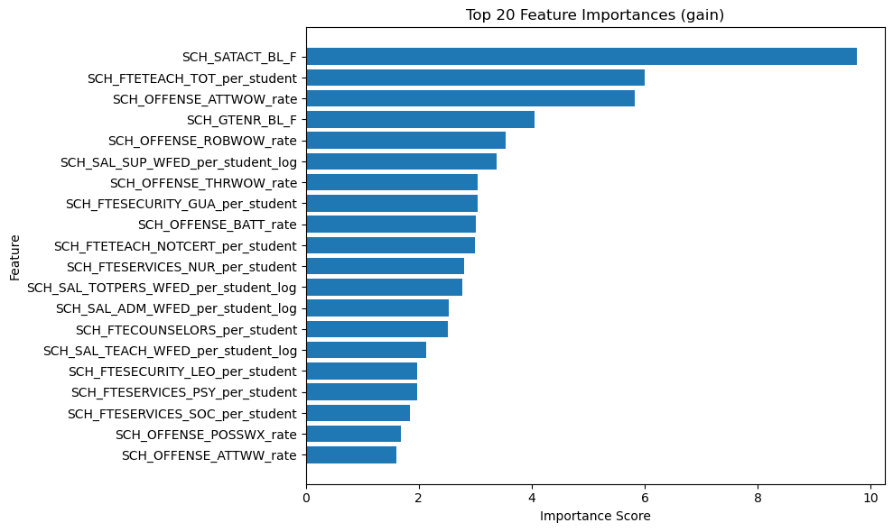

```python
# Get feature importances by gain
importance_type = 'gain'
importance_dict = best_xgb.get_booster().get_score(importance_type=importance_type)

# Convert to DataFrame
importance_df = pd.DataFrame({
    'feature': list(importance_dict.keys()),
    'importance': list(importance_dict.values())
}).sort_values(by='importance', ascending=False)

# Plot
plt.figure(figsize=(10, 6))
plt.barh(importance_df['feature'][:20][::-1], importance_df['importance'][:20][::-1])
plt.title(f'Top 20 Feature Importances ({importance_type})')
plt.xlabel("Importance Score")
plt.ylabel("Feature")
plt.tight_layout()
plt.savefig("xgboost_feature_importance.png", dpi=300, bbox_inches='tight')
plt.show()
```

## IV. Output Interpretation

```python
# Save target_df
target_df.to_csv("target_df_cleaned.csv", index=False)

# Save feature_df
feature_df.to_csv("feature_df_cleaned.csv", index=False)
```

### Improvements:

- DT with Raw Values
- Interpret with SHAP
- Partial Dependence plots
- SHAP Interaction plots
- Sensitivity checks(eg. what happens if you vary the 10% harm threshold? Does model performance or policy conclusions change?)
- Deep Analysis for the future:
  - Spatial analysis, if location data is available (are harmful environments geographically clustered?)
  - dashboard prototype highlighting school-level risk assessments for transparency and advocacy